# Final Project

Philip Elgaard Brett

2022-12-08

#Installing the necessary packages

```r
library(tidyverse)
```

```r
library(ggplot2)
```

#Importing my datasets into R

```r
BNP1 <- read_csv2("Data2/BNP_development.csv")
```

```
## ℹ Using "','" as decimal and "'.'" as grouping mark. Use `read_delim()` for more control.
```

```r
Voting3 <- read_csv2("Data2/Voting.csv")
```

```
## ℹ Using "','" as decimal and "'.'" as grouping mark. Use `read_delim()` for more control.
```

##Inspecting my data Using the str() function it can get an overview of how RStudio reads it.

```r
str(Voting3)
```

```
## spc_tbl_ [306 × 3] (S3: spec_tbl_df/tbl_df/tbl/data.frame)
##  $ Party              : chr [1:306] "S" "S" "S" "S" ...
##  $ Year               : num [1:306] 1971 1973 1975 1977 1979 ...
##  $ Percentage_of_votes: num [1:306] 37.3 25.6 29.9 37 38.3 32.9 31.6 29.3 29.8 37.4 ...
##  - attr(*, "spec")=
##   .. cols(
##   ..   Party = col_character(),
##   ..   Year = col_double(),
##   ..   Percentage_of_votes = col_double()
##   .. )
##  - attr(*, "problems")=<externalptr>
```

I can see that it reads it correctly, with both Year and Percentage of Votes being registered as numeric values, and Party being read as characters

#Plotting my GDP data I’m plotting my data into a graph to show the GDP (BNP in danish) development in Denmark from 1970-2021 Using geom_col() to show the development. Also using the scale_x_continuous function I found on https://www.statology.org/ggplot2-scale_x_continuous/ to make the visualization more precise.

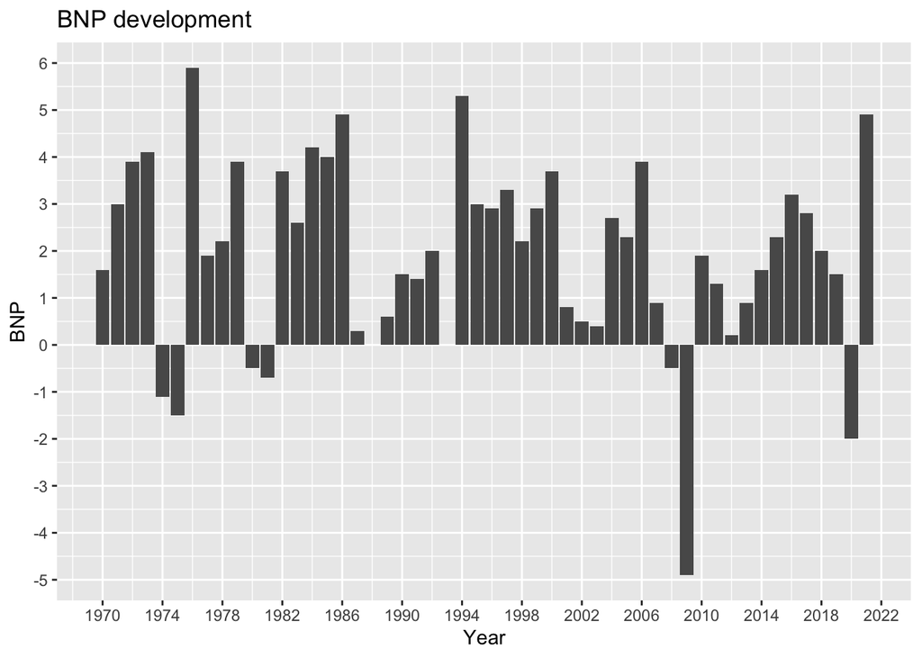

```r
ggplot(data = BNP1) +
  geom_col(aes(x = Year, y = BNP)) +
  scale_y_continuous(breaks = seq(-6, 6, by = 1)) +
  scale_x_continuous(breaks = seq(1970, 2022, by = 4)) +
  labs(title = 'BNP development')
```

##Trying another visualization To get another overlook I plot my data again, this time using geom_line()

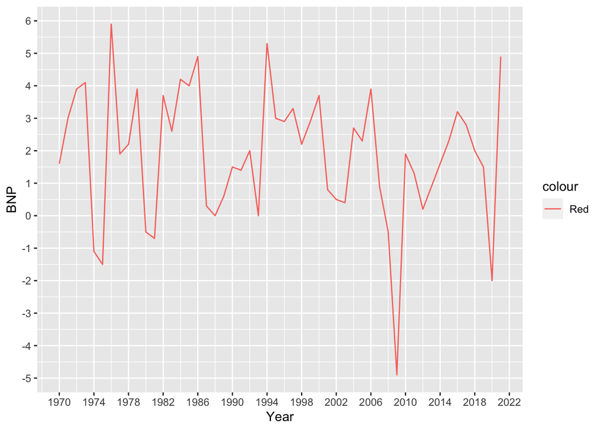

```r
ggplot(data = BNP1) +
  geom_line(aes(x = Year, y = BNP, color = 'Red')) +
    scale_y_continuous(breaks = seq(-6, 6, by = 1)) +
    scale_x_continuous(breaks = seq(1970, 2022, by = 4)) ##Husk at kildehenvise koden
```

#Plotting overall election results Now I am plotting my data on election results from 1971-2019 using geom_col() and adding color.

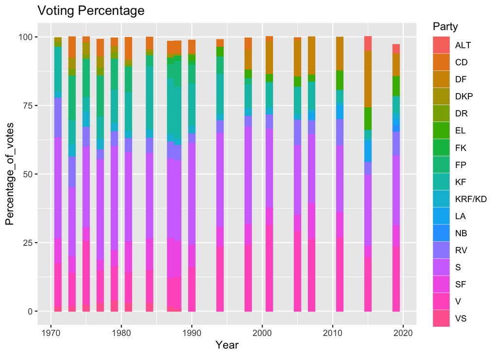

```r
ggplot(data = Voting3) +
  geom_col(aes(x = Year, y = Percentage_of_votes, color = Party, fill=Party)) +
  labs(title = "Voting Percentage")
```

#Plotting overall election results again To get a clearer and more pleasing visualization, I use geom_line() this time

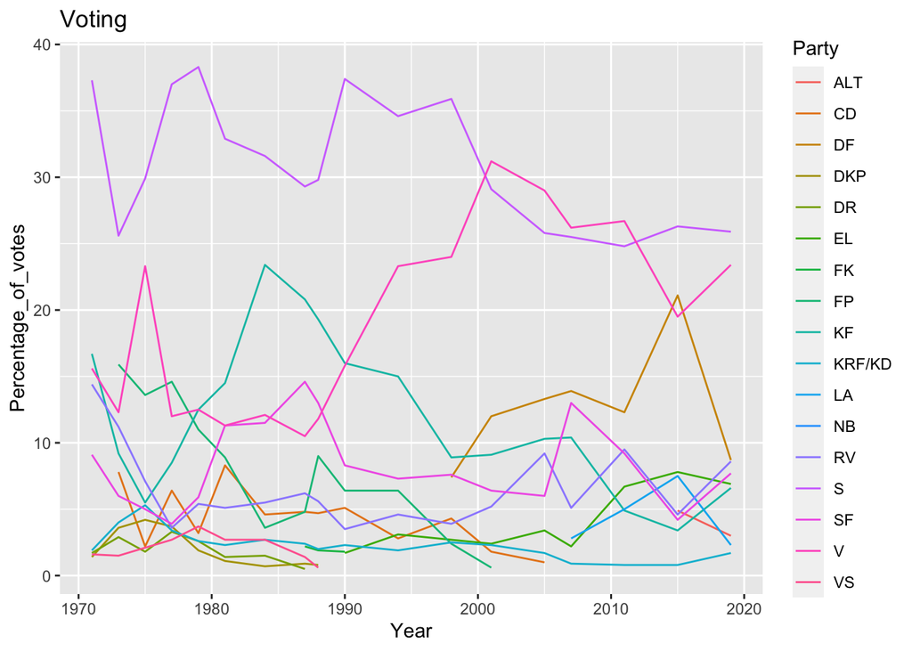

```r
ggplot(data = Voting3) +
  geom_line(mapping = aes(x = Year, y = Percentage_of_votes, color = Party)) +
  labs(title = "Voting")
```

##Merging the parties into groups The visualization above is a bit messy, because of all the different parties, so in order to make the visualizations simpler and more transparent, I will merge the different parties into three groups. Left-wing parties, right-wing parties and center parties. ’

I will use the filter() function so merge the different groups

```r
Left_wing <- Voting3 %>%
  filter(Party == "SF" | Party == "EL" | Party == "ALT" | Party == "VS" | Party == "DKP" | Party == "FK")
```

Now visualizing the data left-wing data with geom_line

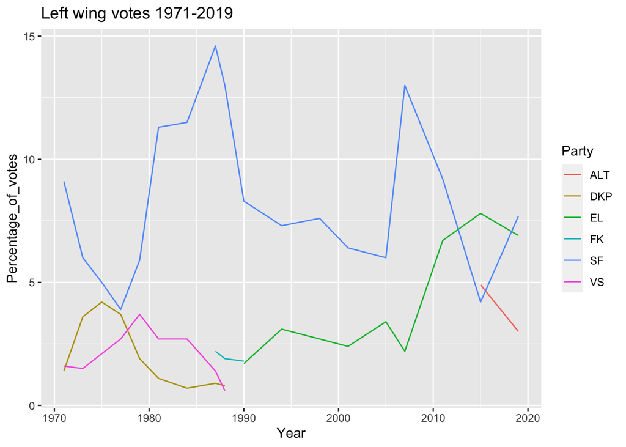

```r
ggplot(data = Left_wing) +
  geom_line(mapping = aes(x = Year, y = Percentage_of_votes, color = Party)) +
  labs(title = "Left wing votes 1971-2019")
```

Now doing the same with right-wing parties

```r
Right_wing <- Voting3 %>%
  filter(Party == "DF" | Party == "FP" | Party == "NB" | Party == "LA")
```

Visualizing the right-wing votes

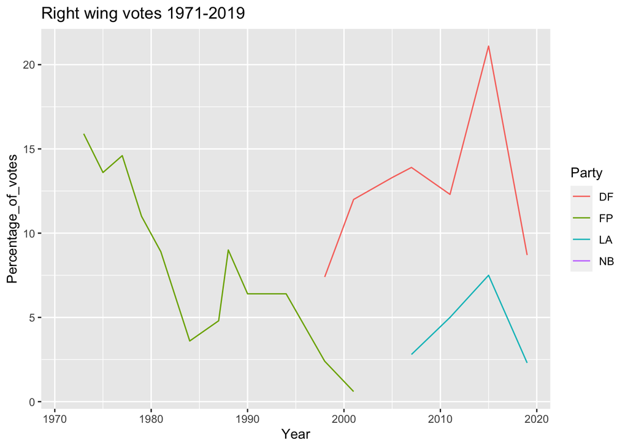

```r
ggplot(data = Right_wing) +
  geom_line(mapping = aes(x = Year, y = Percentage_of_votes, color = Party)) +
  labs(title = "Right wing votes 1971-2019")
```

Merging the danish danish centre parties

```r
Centre_parties <- Voting3 %>%
  filter(Party == "S" | Party == "V" | Party == "KF" | Party == "RV" | Party == "CD" | Party == "DR" | Party == "KRF/KD")
```

Visualizing the center-parties

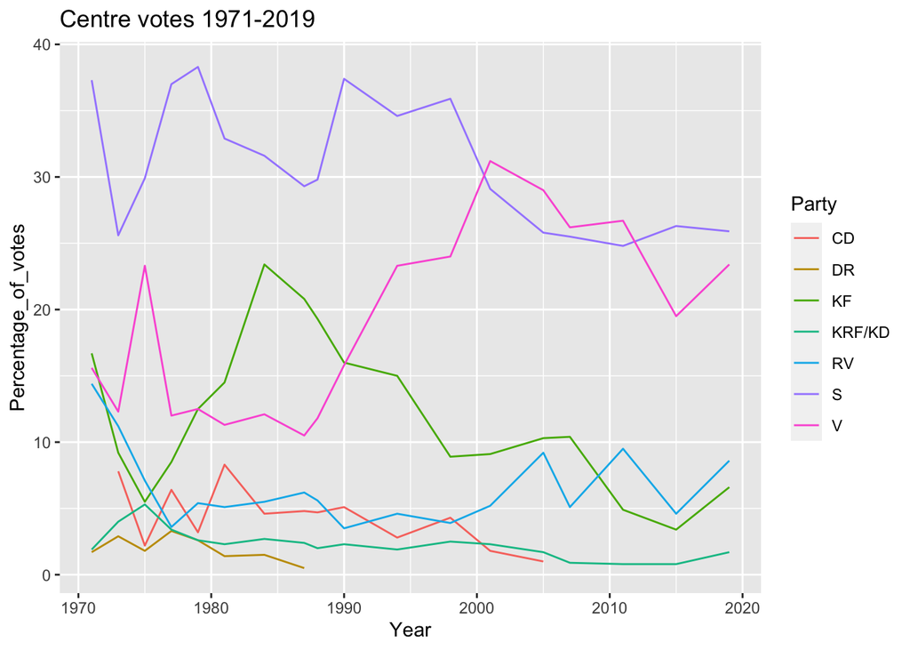

```r
ggplot(data = Centre_parties) +
  geom_line(mapping = aes(x = Year, y = Percentage_of_votes, color = Party)) +
  labs(title = "Centre votes 1971-2019")
```

##Summarizing my Left, Center and Right-wing votes in order to make the final visualisation more straightforward Summarizing my center parties

```r
Centre_parties_summarized <- Centre_parties %>%
  drop_na(Percentage_of_votes) %>%
  group_by(Year) %>%
  summarise(total_block_votes_pct = sum(Percentage_of_votes))
```

Summarizing the Left Wing votes into one group.

```r
Left_parties_summarized <- Left_wing %>%
  drop_na(Percentage_of_votes) %>%
  group_by(Year) %>%
  summarise(total_block_votes_pct = sum(Percentage_of_votes))
```

Summarizing the Right Wing votes into one gruop

```r
Right_parties_summarized <- Right_wing %>%
  drop_na(Percentage_of_votes) %>%
  group_by(Year) %>%
  summarise(total_block_votes_pct = sum(Percentage_of_votes))
```

##Visualizating the three groups Now showing the three groups together with geom_line()

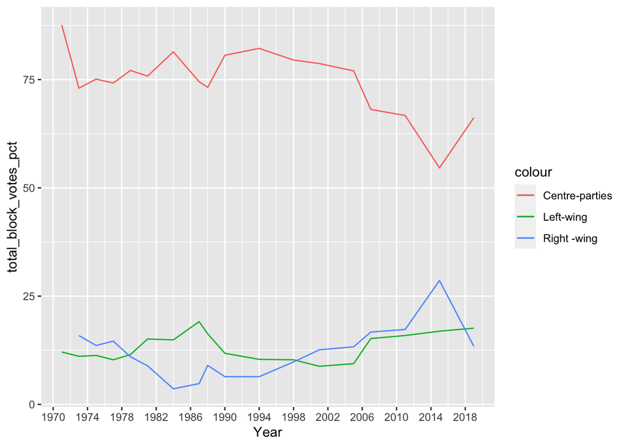

```r
ggplot() +
   geom_line(data = Left_parties_summarized, aes(x = Year, y = total_block_votes_pct, color = "Left-wing")) +
  geom_line(data = Right_parties_summarized, aes(x = Year, y = total_block_votes_pct, color = "Right -wing")) +
  geom_line(data = Centre_parties_summarized, aes( x= Year, y = total_block_votes_pct, color = "Centre-parties")) +
  scale_x_continuous(breaks = seq(1970, 2022, by = 4))
```

##Visualizing GDP development and voting trends together Applying multiple dataframes to show GDP development and election results together and making them easier to compare.

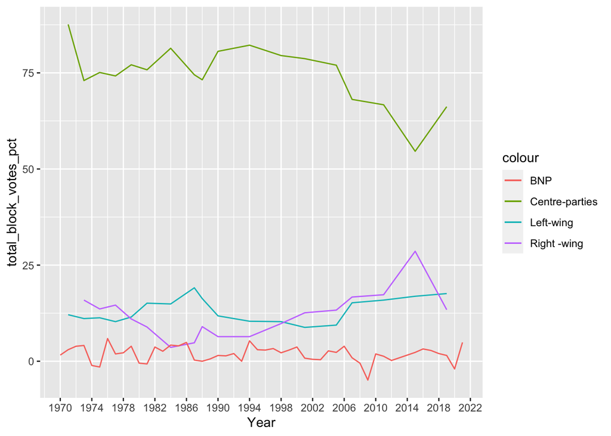

```r
ggplot() +
  geom_line(data = Left_parties_summarized, aes(x = Year, y = total_block_votes_pct, color = "Left-wing")) +
  geom_line(data = Right_parties_summarized, aes(x = Year, y = total_block_votes_pct, color = "Right -wing")) +
  geom_line(data = Centre_parties_summarized, aes( x= Year, y = total_block_votes_pct, color = "Centre-parties")) +
  geom_line(data = BNP1, aes(x = Year, y = BNP1$BNP, color = "BNP")) +
  scale_x_continuous(breaks = seq(1970, 2022, by = 4))
```

#Conclusion I can now see if there is any correlation between the fluctuation in the GDP development and election results.